# Coursera Practial Machine Learning project

Steven Devisch

April 30, 2016

## Introduction

Using devices such as Jawbone Up, Nike FuelBand, and Fitbit it is now possible to collect a large amount of data about personal activity relatively inexpensively.

These type of devices are part of the quantified self movement - a group of enthusiasts who take measurements about themselves regularly to improve their health, to find patterns in their behavior, or because they are tech geeks.

One thing that people regularly do is quantify how much of a particular activity they do, but they rarely quantify how well they do it.

In this project, your goal will be to use data from accelerometers on the belt, forearm, arm, and dumbell of 6 participants.

The goal of the project is to predict the manner in which participatns did the exercise. This is the “classe” variable in the training set.

We shall describe how we  
* built our model, * how we performed cross validation, * what we think the expected out of sample error is, * why we made specific choices, and * how we used our prediction model to predict 20 different test cases

## Load train and test data sets and identify NA’s

```r
trainUrl <- "http://d396qusza40orc.cloudfront.net/predmachlearn/pml-training.csv"
testUrl <- "http://d396qusza40orc.cloudfront.net/predmachlearn/pml-testing.csv"
trainData <- read.csv(url(trainUrl), header=TRUE, sep=",", na.strings=c("NA","#DIV/0!",""))
testData <- read.csv(url(testUrl), header=TRUE, sep=",", na.strings=c("NA","#DIV/0!",""))
```

## Data cleaning

Note that the column “class” is not included in the test dataset as the feature classe is the purpose of the prediction effort.

## Model 1: tree model with rPart

```r
# set seed for reproducibility
set.seed(12345)
rpart1 <-train(classe~.,method="rpart", data=trainDSS)
print(rpart1$finalModel)
```

```
## n= 13737
##
## node), split, n, loss, yval, (yprob)
##       * denotes terminal node
##
##  1) root 13737 9831 A (0.28 0.19 0.17 0.16 0.18)
##    2) roll_belt< 130.5 12576 8676 A (0.31 0.21 0.19 0.18 0.11)
##      4) pitch_forearm< -33.95 1093    6 A (0.99 0.0055 0 0 0) *
##      5) pitch_forearm>=-33.95 11483 8670 A (0.24 0.23 0.21 0.2 0.12)
##       10) magnet_dumbbell_y< 439.5 9696 6939 A (0.28 0.18 0.24 0.19 0.11)
##         20) roll_forearm< 121.5 6015 3547 A (0.41 0.18 0.19 0.16 0.058) *
##         21) roll_forearm>=121.5 3681 2492 C (0.079 0.18 0.32 0.23 0.18) *
##       11) magnet_dumbbell_y>=439.5 1787  890 B (0.031 0.5 0.042 0.23 0.19) *
##    3) roll_belt>=130.5 1161    6 E (0.0052 0 0 0 0.99) *
```

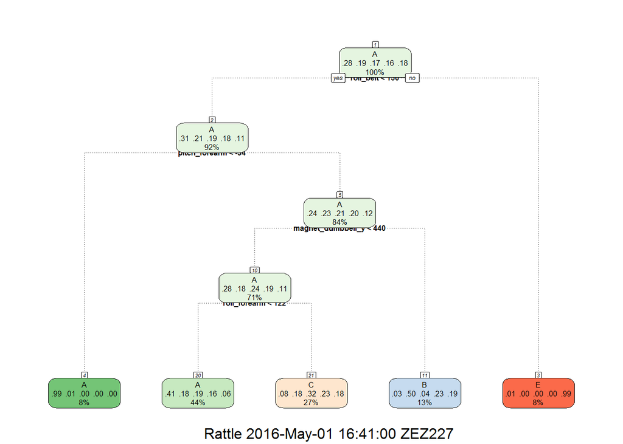

```r
fancyRpartPlot(rpart1$finalModel,cex=.5,under.cex=1,shadow.offset=0)
```

## Model 2: random forests

### Model build

```r
# set seed for reproducibility
forestTrainFit <- randomForest(classe ~ ., data=trainDSS)
testPredict <- predict(forestTrainFit, testDSS, type = "class")
confusionForest <- confusionMatrix(testPredict, testDSS$classe)
confusionForest
```

```
## Confusion Matrix and Statistics
##
##           Reference
## Prediction    A    B    C    D    E
##          A 1674    3    0    0    0
##          B    0 1131    3    0    1
##          C    0    5 1023    7    0
##          D    0    0    0  956    3
##          E    0    0    0    1 1078
##
## Overall Statistics
##
##                Accuracy : 0.9961
##                  95% CI : (0.9941, 0.9975)
##     No Information Rate : 0.2845
##     P-Value [Acc > NIR] : < 2.2e-16
##
##                   Kappa : 0.9951
##  Mcnemar's Test P-Value : NA
##
## Statistics by Class:
##
##                      Class: A Class: B Class: C Class: D Class: E
## Sensitivity            1.0000   0.9930   0.9971   0.9917   0.9963
## Specificity            0.9993   0.9992   0.9975   0.9994   0.9998
## Pos Pred Value         0.9982   0.9965   0.9884   0.9969   0.9991
## Neg Pred Value         1.0000   0.9983   0.9994   0.9984   0.9992
## Prevalence             0.2845   0.1935   0.1743   0.1638   0.1839
## Detection Rate         0.2845   0.1922   0.1738   0.1624   0.1832
## Detection Prevalence   0.2850   0.1929   0.1759   0.1630   0.1833
## Balanced Accuracy      0.9996   0.9961   0.9973   0.9955   0.9980
```

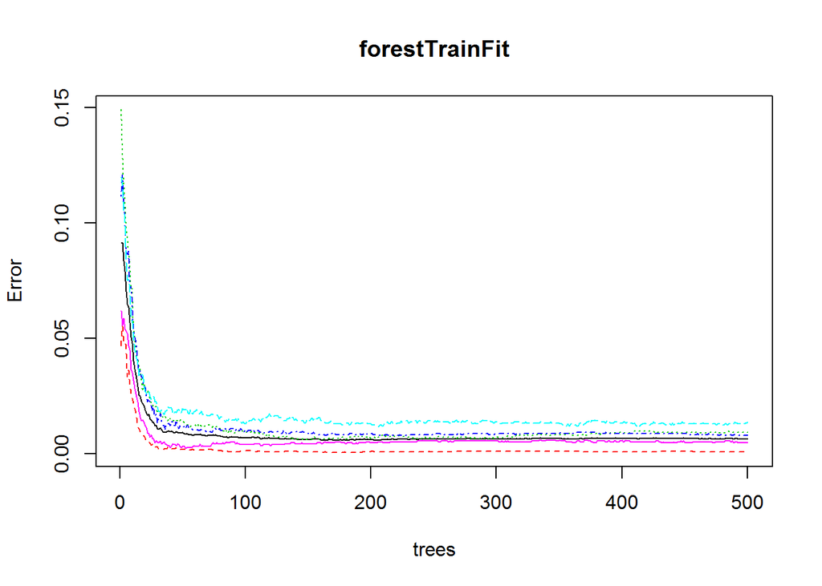

```r
plot(forestTrainFit)
```

### Applying the prediction model to predict 20 different test cases

We shal proceed to predict the class variable for the test dataset.

```r
testDataPredict <- predict(forestTrainFit, testData)
testDataPredict
```

```
##  1  2  3  4  5  6  7  8  9 10 11 12 13 14 15 16 17 18 19 20
##  B  A  B  A  A  E  D  B  A  A  B  C  B  A  E  E  A  B  B  B
## Levels: A B C D E
```